# Supplemental Material: Non-stationary population dynamics in Pacific salmon through an era of widespread ecological change

Greenberg et al.

2026

# 1 Overview

This document contains additional figures exploring the characteristics of the spawner-recruitment relationships for 356 Pacific salmon populations throughout the Northeast Pacific region.

## 1.1 Table S1. Overview of Time-series

Overview of spawner-recruit time-series included in the compilation.

| species | stock | start.year | end.year | region | ocean.region |
| --- | --- | --- | --- | --- | --- |
| Chinook | Ayakulik | 1977 | 2009 | Kodiak | GoA |
| Chinook | Karluk | 1976 | 2009 | Kodiak | GoA |
| Chinook | Chignik | 1980 | 2008 | AK Peninsula | GoA |
| Chinook | Nelson | 1981 | 1996 | AK Peninsula | GoA |
| Chinook | Goodnews | 1981 | 2001 | Kuskokwim | BS |
| Chinook | Andrew Creek | 1979 | 2004 | SEAK | NC |
| Chinook | Chickamin | 1985 | 2004 | SEAK | NC |
| Chinook | King Salmon River | 1982 | 2004 | SEAK | NC |
| Chinook | Stikine | 1977 | 1997 | SEAK | NC |
| Chinook | Unuk | 1982 | 2004 | SEAK | NC |
| Chinook | Alsek | 1976 | 1990 | SEAK | NC |
| Chinook | Situk | 1977 | 1998 | SEAK | NC |
| Chinook | Nushagak | 1966 | 2005 | Bristol Bay | BS |
| Chinook | Copper | 1980 | 2015 | Central AK | GoA |
| Chinook | Deshka | 1979 | 2014 | Central AK | GoA |
| Chinook | Susitna | 1979 | 2014 | Central AK | GoA |
| Chinook | Talkeetna | 1979 | 2014 | Central AK | GoA |
| Chinook | Yentna | 1979 | 2014 | Central AK | GoA |
| Chinook | Kenai | 1986 | 2016 | Central AK | GoA |
| Chinook | Kenai | 1986 | 2016 | Central AK | GoA |
| Chinook | Blossom | 1975 | 2001 | SEAK | NC |
| Chinook | Keta | 1975 | 2001 | SEAK | NC |
| Chinook | Anchor | 2003 | 2013 | Central AK | GoA |
| Chinook | East Fork Andreafsky | 1994 | 2010 | Yukon | BS |
| Chinook | Gisasa | 1995 | 2010 | Yukon | BS |
| Chinook | Salcha | 1987 | 2016 | Yukon | BS |
| Chinook | Chena | 1986 | 2016 | Yukon | BS |
| Chinook | Aniak | 1977 | 2010 | Kuskokwim | BS |
| Chinook | George | 1976 | 2010 | Kuskokwim | BS |
| Chinook | Holokuk | 1976 | 2010 | Kuskokwim | BS |

[output cut: 326 more lines]

## 1.2 Fig. S1. Time-series length

Distribution of spawner-recruit time-series lengths (number of years of brood cohort observations) broken down by species. Vertical lines indicate the median value.

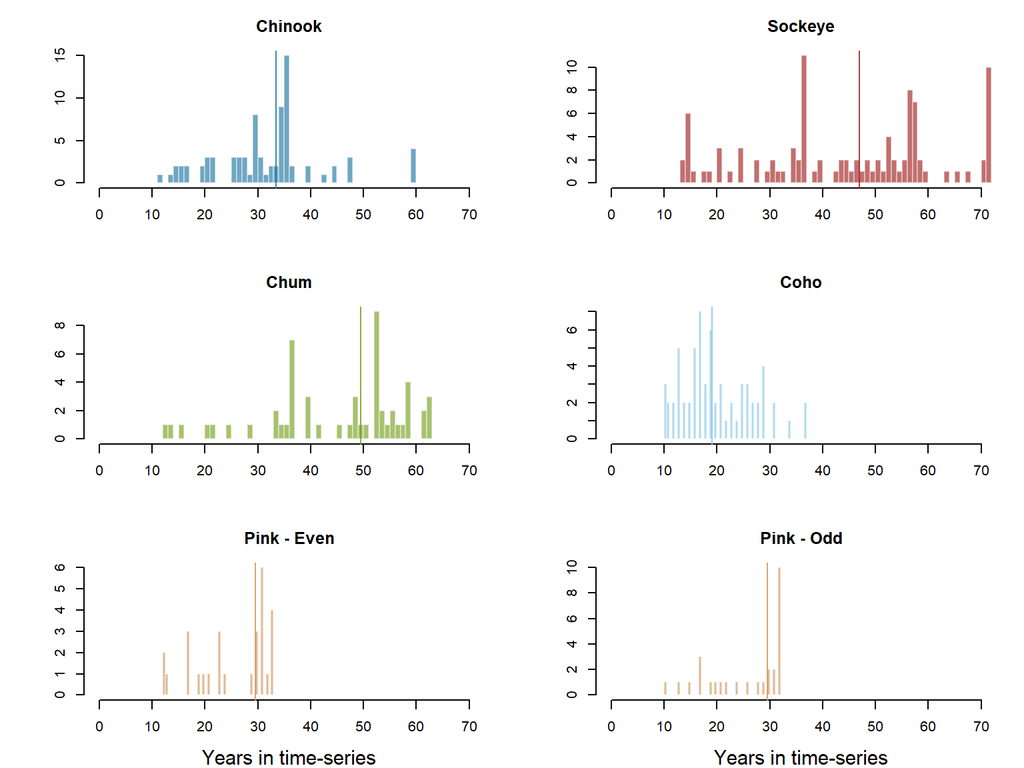

Distribution of spawner-recruit time-series lengths by species

## 1.3 Fig. S2. Ratio of Capacity (Smax) to maximum observed spawners

To assess whether these priors are justifiable, we applied Maximum Likelihood Estimates of the standard Ricker model (with 1-year autocorrelation) to each spawner-recruit series individually using Template Model Builder (TMB). We subsequently estimate the ratio of this prior-free $S_{max}$ to the maximum observed spawners in each series to yield this distribution. Note that some stocks were trimmed that had extreme ratios (~2%, >10x maximum observed spawners), highlighting the advantage of informative priors in these cases.

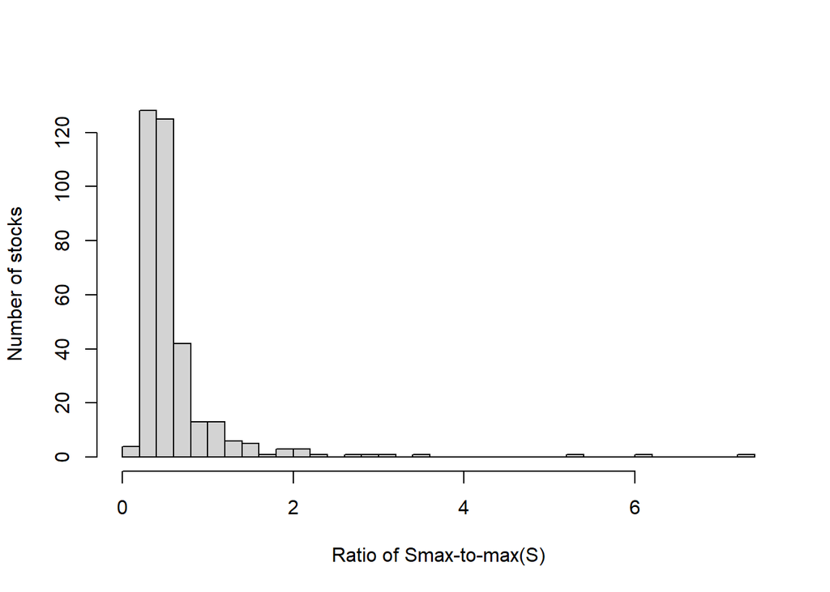

```
[1] "5 stock estimates excluded from plot (ratio >10x)"
```

# 2 Comparison of random walk vs. GAM nonstationary formulations

We considered an alternative parameterization of the multi-stock nonstationary dynamics model based upon a hierarchical generalized additive model. In this framework, the stock-specific intrinsic productivity at each time-step (ie. $log \alpha_{j,t}$) is a hierarchical deviation from shared ocean region ($log \alpha_{or,t}$) and global estimates ($log \alpha_{0,t}$〗). In the GAM framework, time-varying productivity estimates emerge as the product of a B-spline design matrix of $K$ basis functions representing the span of observed brood cohort years ($B_{t,k}$) and $K$ spline coefficients at stock-specific ($\omega_{j,k}$), ocean region ($\omega_{or,k}$), and global population scales ($\omega_{0,k}$) that are drawn from nested hierarchical distributions, which acts to smooth the spline coefficients and penalize overfitting (Wand 2003).

$$log(R_{j,t}/S_{j,t}) = log \alpha_{j,t} - S_{j,t}/S_{max,j} + \epsilon_{j,t}$$
$$log \alpha_{j,t} = log \alpha_{j} + \sum_{k=1}^{K} \omega_{j,k} \times B_{t,k}$$
$$log \alpha_{or,t} = log \alpha_{or} + \sum_{k=1}^{K} \omega_{or,k} \times B_{t,k}$$
$$log \alpha_{0,t} = log \alpha_{0} + \sum_{k=1}^{K} \omega_{0,k} \times B_{t,k}$$
$$log \alpha_{j} \sim N(log \alpha_{sr}, \sigma_{\alpha,j})$$
$$log \alpha_{sr} \sim N(log \alpha_{or}, \sigma_{\alpha,sr})$$
$$log \alpha_{or} \sim N(log \alpha_{0}, \sigma_{\alpha,or})$$
$$log \alpha_{0} \sim N(1.5, 4)$$
$$\omega_{j,k} \sim N(\omega_{or,k}, \sigma_{\omega,j})$$
$$\omega_{or,k} \sim N(\omega_{0,k}, \sigma_{\omega,or})$$
$$\omega_{0,k} \sim N(0, \sigma_{\omega})$$
$$S_{max,j} \sim N(0.5 \times max(S_{j,t}), (2 \times max(S_{j,t})))$$
$$\epsilon_{j,t} \sim N(0, \sigma_{v,j})$$
$$\sigma_{\alpha,j}/\sigma_{\alpha,sr}/\sigma_{\alpha,or} \sim N(0, 1)$$
$$\sigma_{\omega,j}/\sigma_{\omega,or}/\sigma_{\omega} \sim N(0, 1)$$
$$\sigma_{v,j} \sim Gamma(2, 1)$$

The piecewise polynomials generated in the $N \times K$ B-spline design matrix ($B_{t,k}$) can be set at varying polynomial degrees (e.g. linear, quadratic, cubic, etc.), and the number and placement of the knots can also influence the resulting smoothed function. We generated B-spline matrices using the splines R package with cubic polynomials, which are commonly used in GAMs (Ward et al. 2022), at every 2 years from the beginning to end of the entire brood cohort series for each species to compare to the multi-stock independent random walk model presented in the main manuscript.

## 2.1 Fig. S3 - GAM vs. random walk comparison

Stock-specific productivity (log$\alpha_{j,t}$) trajectories from either individual random walks (A: model presented in main results) or from a hierarchical GAM model (B). Lines indicate median posterior estimates.

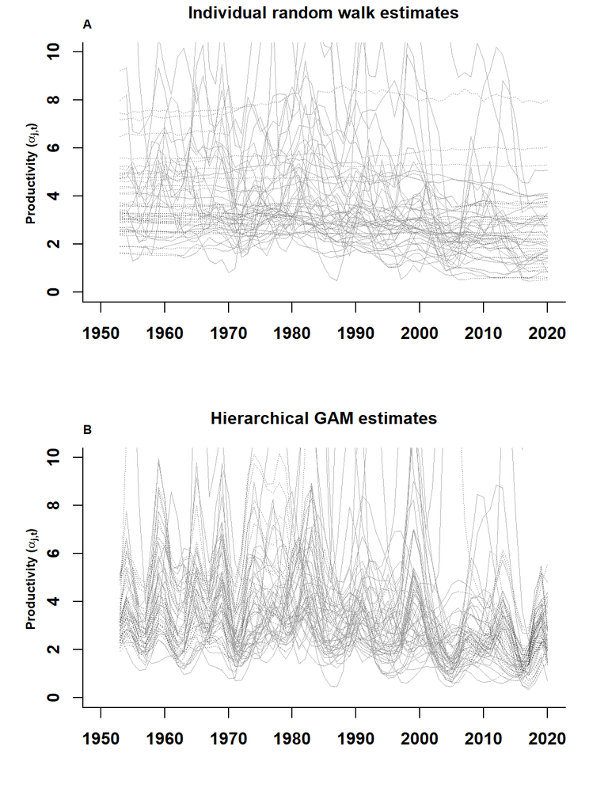

Comparison of the variance in stock-level productivity trajectories for all Chum stocks estimated with either - individual stock-specific random walks in intrinsic productivity (A; following the methodology presented in the main manuscript) or hierarchically estimated deviations from shared GAM estimates (B; as per the formulation above). Each line represents the median estimate of productivity for an individual stock, dotted lines indicate time periods without observations for that particular time-series.

## 2.2 Fig. S4- GAM vs. random walk comparison by ocean region

Comparison of productivity trajectories by ocean region for Chum salmon comparing population mean productivity estimates by region (A; following the methodology presented in the main manuscript) or hierarchically estimated deviations from a global GAM estimate (B; as per the formulation above). Shading indicates 90% highest posterior density intervals for the mean trajectory and the bold lines represent the median estimates. The transparency of the bold line reflects the proportion of time-series with observations in a given year.

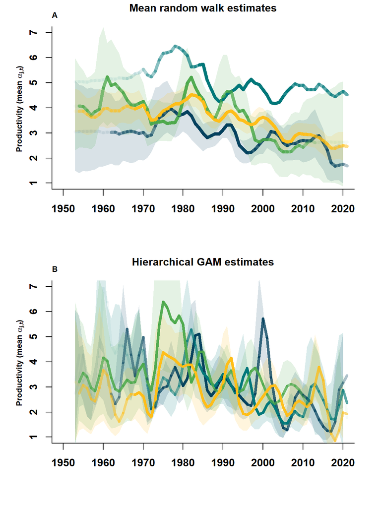

From these visualizations we can determine several things. First, that the GAM implementation of the nonstationary dynamics model significantly reduces stock-level variability in productivity trajectories through the hierarchical piece-wise polynomials (Fig. S3). This results in unobserved parts of the inferences (ie. where no observations exist for a stock in a given year) closely following the population mean for those stocks that were observed (see the dotted portions of the median estimates in Fig. S3). The result is that group-level inferences, such as the hierarchical means estimated by ocean region , from the GAM framework are much more variable over time when compared to mean estimates of the individual random walks (Fig. S4). This reflects the partial pooling of the hierarchical estimates being more liable to shift based on the observed samples. For this reason, we believe that the means of the individual random walk model is a more conservative estimate of productivity change - as it assumes, in the absence of evidence (observations), no change in the missing time-series rather than change proportional to the observed series for that period.

## 2.3 Fig. S5 - Smax comparison between GAM and random walk

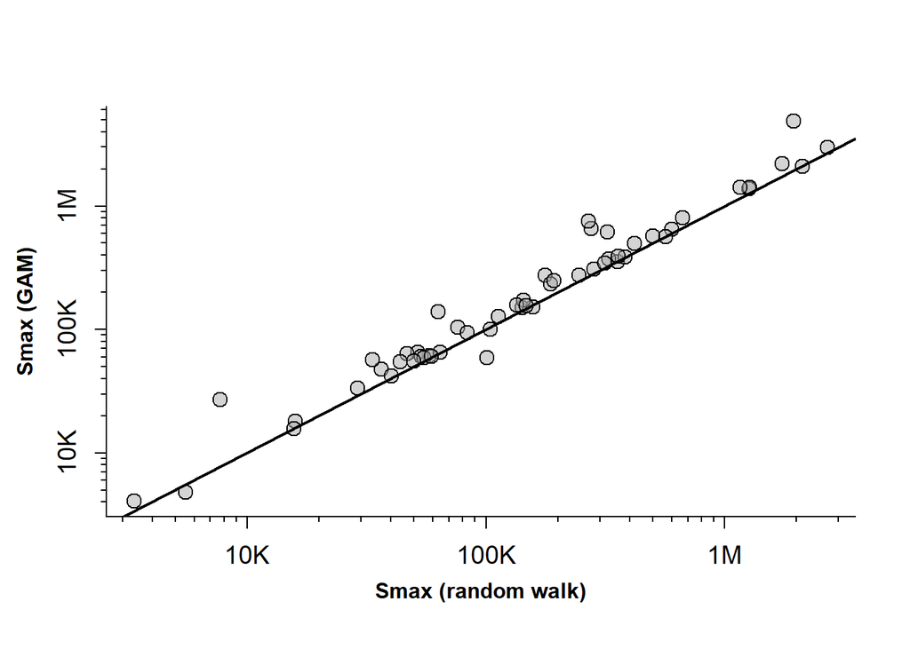

```
   Min. 1st Qu.  Median    Mean 3rd Qu.    Max.
 0.5835  1.0536  1.1251  1.2886  1.2543  3.5215
```

## 2.4 Table S2. Recent mean productivity (last 10 brood cohorts) and Umsy by sub-region

Mean productivity (in units of log(R/S)), and standard deviation of mean productivity, for last 10 brood cohorts for each species by sub-region: Chinook (2010-2020), Sockeye (2009-2019), Chum (2010-2020), Coho (2006-2016), even-year Pink (2014-2024), odd-year Pink (2013-2023).

[output not shown]

## 2.5 Table S3. Productivity trends by ocean region

Estimates of mean annual changes in productivity, for each species and ocean region indicating the mean and standard deviation of the posterior estimates.

| species | ocean.region | n | mean | sd |
| --- | --- | --- | --- | --- |
| Chinook | South Coast | 24 | -2.08 | 0.40 |
| Chinook | North Coast | 15 | -1.32 | 0.34 |
| Chinook | Gulf of Alaska | 16 | -1.65 | 0.40 |
| Chinook | Bering Sea | 25 | -2.87 | 0.23 |
| Chum | South Coast | 21 | -0.61 | 0.15 |
| Chum | North Coast | 10 | -0.18 | 0.65 |
| Chum | Gulf of Alaska | 12 | -0.65 | 0.37 |
| Chum | Bering Sea | 11 | -1.07 | 0.37 |
| Coho | South Coast | 38 | -0.67 | 0.33 |
| Coho | North Coast | 24 | -0.83 | 0.36 |
| Coho | Gulf of Alaska | 3 | 0.03 | 1.07 |
| Pink (even) | South Coast | 4 | -0.89 | 0.44 |
| Pink (even) | North Coast | 11 | 0.10 | 0.45 |
| Pink (even) | Gulf of Alaska | 7 | -0.48 | 0.55 |
| Pink (even) | Bering Sea | 6 | -0.45 | 0.94 |
| Pink (odd) | South Coast | 10 | -0.24 | 0.30 |
| Pink (odd) | North Coast | 6 | -0.33 | 1.13 |
| Pink (odd) | Gulf of Alaska | 7 | 0.36 | 0.84 |
| Pink (odd) | Bering Sea | 5 | -0.04 | 1.11 |
| Sockeye | South Coast | 44 | -2.67 | 0.49 |
| Sockeye | North Coast | 28 | -1.10 | 0.20 |
| Sockeye | Gulf of Alaska | 17 | -0.51 | 0.20 |
| Sockeye | Bering Sea | 12 | 1.12 | 0.20 |

## 2.6 Fig. S6. Productivity trends as a function of Smax

Estimates of annual changes in productivity by stock (calculated as % change in $log(\alpha)$), for each species, as a function of stock size, as measured by $S_{max}$. $r$ indicates the median correlation and 90% highest posterior density intervals between the posteriors of both quantities.

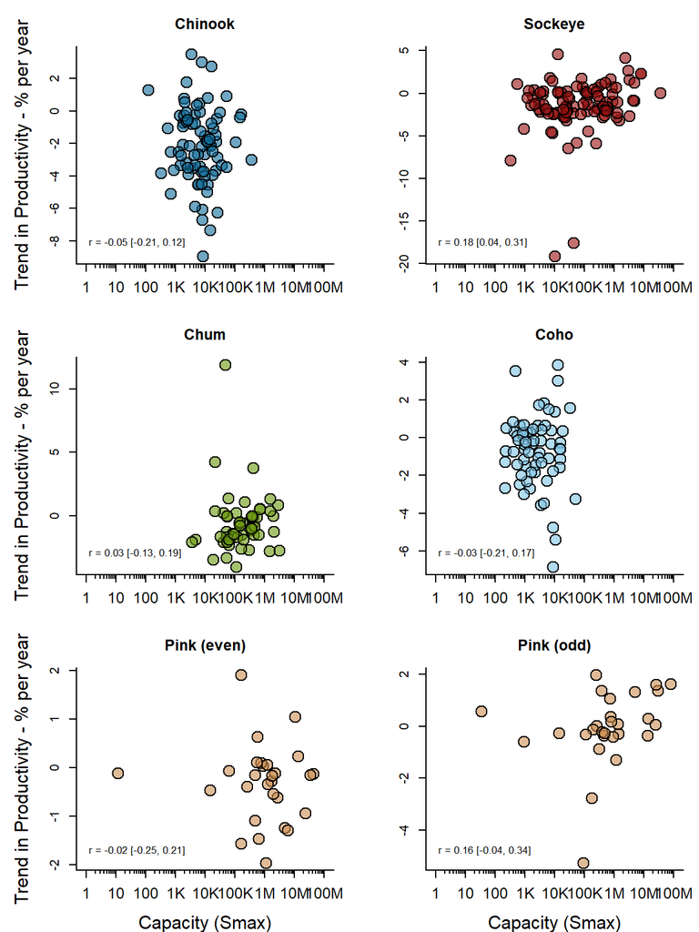

# 3 Static model - stock parameters

For each species, we fit a multi-stock Ricker spawner-recruit model with static parameters (model 1 in main text). Stock-specific productivity ($\alpha_j$) is hierarchically structured based on geography (ie. stocks are nested within sub-regions, which are nested within ocean regions, which are nested in a coastwide estimate). All other parameters are sampled independently for each stock. We present the distributions for each key parameter summarized at different population scales, as these can serve as useful priors in data-limited systems.

## 3.1 Fig. S7. Coastwide productivity posteriors by species

Posterior estimates of mean productivity, log($\alpha$), among all stocks, for each species. Vertical lines indicate the posterior median.

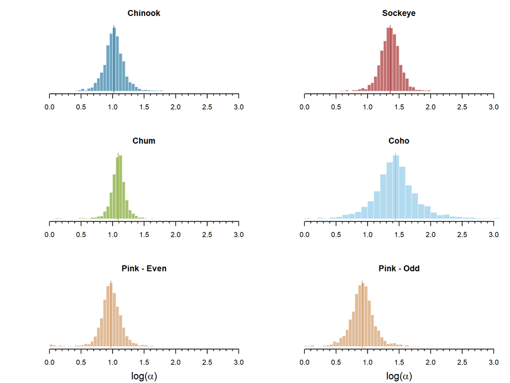

## 3.2 Table S4. Coastwide productivity by species

Posterior estimates of mean productivity, log($\alpha$), for each Pacific salmon species. mean = mean of posterior, sd = standard deviation of posterior.

| species | mean | sd |
| --- | --- | --- |
| Chinook | 1.02 | 0.18 |
| Sockeye | 1.35 | 0.18 |
| Chum | 1.08 | 0.15 |
| Coho | 1.45 | 0.38 |
| Pink (even) | 0.97 | 0.20 |
| Pink (odd) | 0.92 | 0.22 |

## 3.3 Fig. S7. Ocean Basin Productivity

Posterior estimates of mean productivity for stocks each ocean region in the Northeast Pacific. Vertical lines indicate medians for each region.

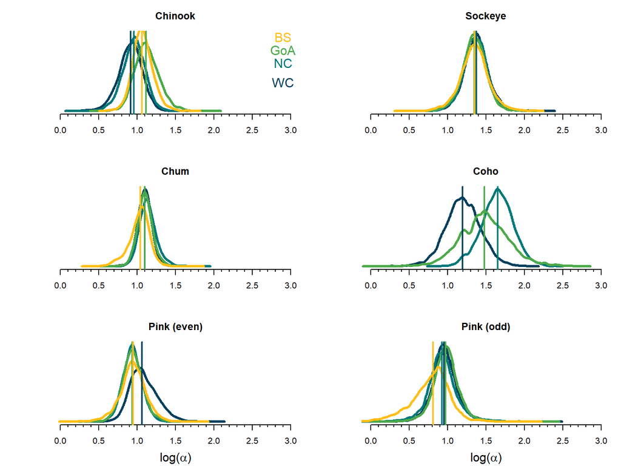

## 3.4 Table S3. Ocean Basin Productivity

Posterior estimates of mean productivity, log($\alpha$), by ocean region for each Pacific salmon species. mean = mean of posterior, sd = standard deviation of posterior.

| species | ocean.region | n | mean | sd |
| --- | --- | --- | --- | --- |
| Chinook | South Coast | 24 | 1.07 | 0.13 |
| Chinook | North Coast | 15 | 1.13 | 0.16 |
| Chinook | Gulf of Alaska | 16 | 0.95 | 0.15 |
| Chinook | Bering Sea | 25 | 0.91 | 0.16 |
| Chum | South Coast | 21 | 1.02 | 0.14 |
| Chum | North Coast | 10 | 1.10 | 0.10 |
| Chum | Gulf of Alaska | 12 | 1.14 | 0.12 |
| Chum | Bering Sea | 11 | 1.10 | 0.09 |
| Coho | South Coast | 38 | 1.48 | 0.32 |
| Coho | North Coast | 24 | 1.65 | 0.21 |
| Coho | Gulf of Alaska | 3 | 1.20 | 0.23 |
| Pink (even) | South Coast | 4 | 0.94 | 0.18 |
| Pink (even) | North Coast | 11 | 0.94 | 0.14 |
| Pink (even) | Gulf of Alaska | 7 | 0.94 | 0.13 |
| Pink (even) | Bering Sea | 6 | 1.08 | 0.18 |
| Pink (odd) | South Coast | 10 | 0.78 | 0.26 |
| Pink (odd) | North Coast | 6 | 0.98 | 0.18 |
| Pink (odd) | Gulf of Alaska | 7 | 0.93 | 0.20 |
| Pink (odd) | Bering Sea | 5 | 0.96 | 0.18 |
| Sockeye | South Coast | 44 | 1.35 | 0.19 |
| Sockeye | North Coast | 28 | 1.34 | 0.16 |
| Sockeye | Gulf of Alaska | 17 | 1.36 | 0.16 |
| Sockeye | Bering Sea | 12 | 1.37 | 0.17 |

## 3.5 Sub-Regional Productivity

Figures S5-S10. Mean productivity, log($\alpha$), estimated for all sub-regions, representing either shared large watersheds or adjacent coastal areas, for each species. Vertical lines indicate the posterior median value and the numbers in parenthesis for each region indicate the stock sample size.

Tables S2-S7. Estimates of mean productivity, log($\alpha$), by sub-region for each species, including the posterior mean (mean), the standard deviation of the mean (sd).

## 3.6 Fig. S8. Chinook sub-region productivity

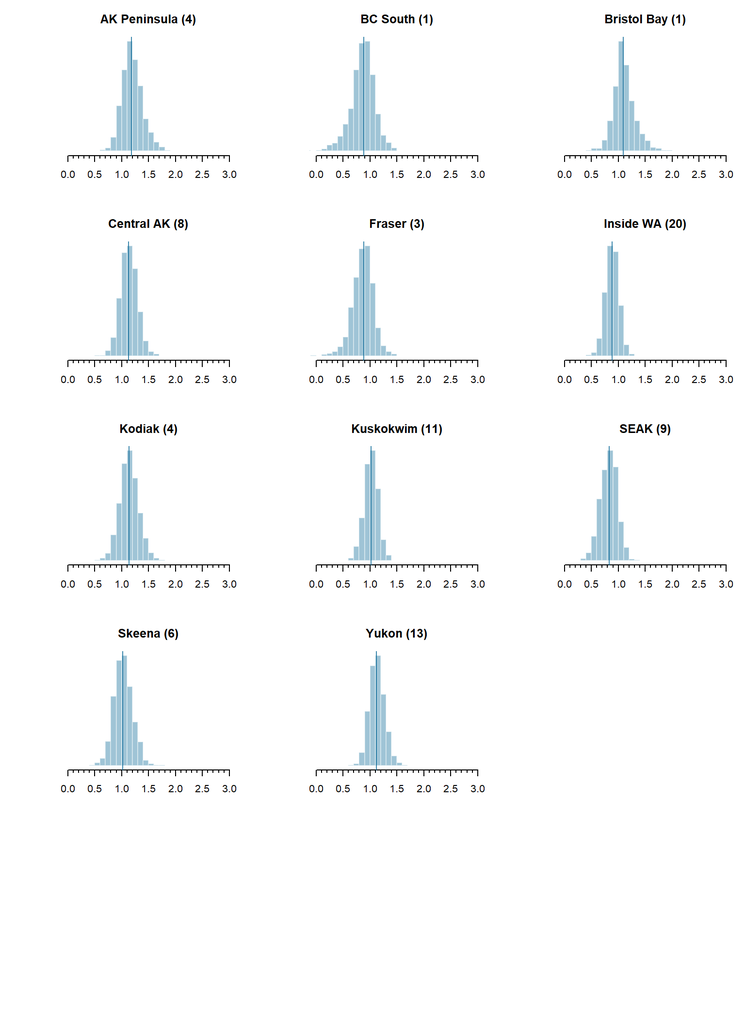

## 3.7 Table S4. Chinook sub-region productivity

|  | region | n | mean | sd |
| --- | --- | --- | --- | --- |
| log_a_sr[1] | AK Peninsula | 4 | 1.20 | 0.19 |
| log_a_sr[2] | BC South | 1 | 0.87 | 0.23 |
| log_a_sr[3] | Bristol Bay | 1 | 1.12 | 0.21 |
| log_a_sr[4] | Central AK | 8 | 1.14 | 0.16 |
| log_a_sr[5] | Fraser | 3 | 0.87 | 0.19 |
| log_a_sr[6] | Inside WA | 20 | 0.89 | 0.12 |
| log_a_sr[7] | Kodiak | 4 | 1.14 | 0.17 |
| log_a_sr[8] | Kuskokwim | 11 | 1.02 | 0.13 |
| log_a_sr[9] | SEAK | 9 | 0.83 | 0.16 |
| log_a_sr[10] | Skeena | 6 | 1.03 | 0.17 |
| log_a_sr[11] | Yukon | 13 | 1.13 | 0.14 |

## 3.8 Fig. S9. Sockeye sub-region productivity

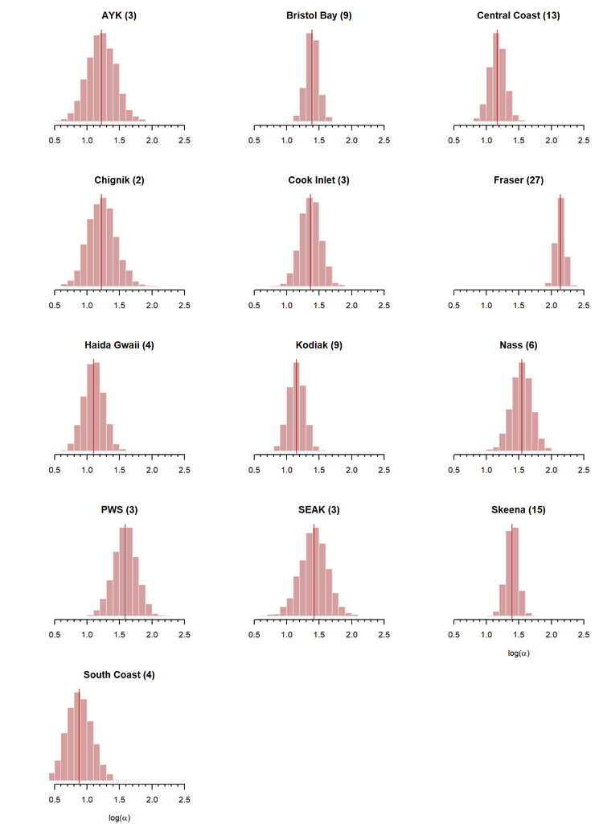

## 3.9 Table S5. Sockeye sub-region productivity

|  | region | n | mean | sd |
| --- | --- | --- | --- | --- |
| log_a_sr[1] | AYK | 3 | 1.22 | 0.22 |
| log_a_sr[2] | Bristol Bay | 9 | 1.39 | 0.10 |
| log_a_sr[3] | Central Coast | 13 | 1.17 | 0.12 |
| log_a_sr[4] | Chignik | 2 | 1.23 | 0.21 |
| log_a_sr[5] | Cook Inlet | 3 | 1.36 | 0.16 |
| log_a_sr[6] | Fraser | 27 | 2.14 | 0.07 |
| log_a_sr[7] | Haida Gwaii | 4 | 1.10 | 0.15 |
| log_a_sr[8] | Kodiak | 9 | 1.15 | 0.12 |
| log_a_sr[9] | Nass | 6 | 1.54 | 0.16 |
| log_a_sr[10] | PWS | 3 | 1.59 | 0.18 |
| log_a_sr[11] | SEAK | 3 | 1.41 | 0.21 |
| log_a_sr[12] | Skeena | 15 | 1.40 | 0.09 |
| log_a_sr[13] | South Coast | 4 | 0.88 | 0.20 |

## 3.10 Fig. S10. Chum sub-region productivity

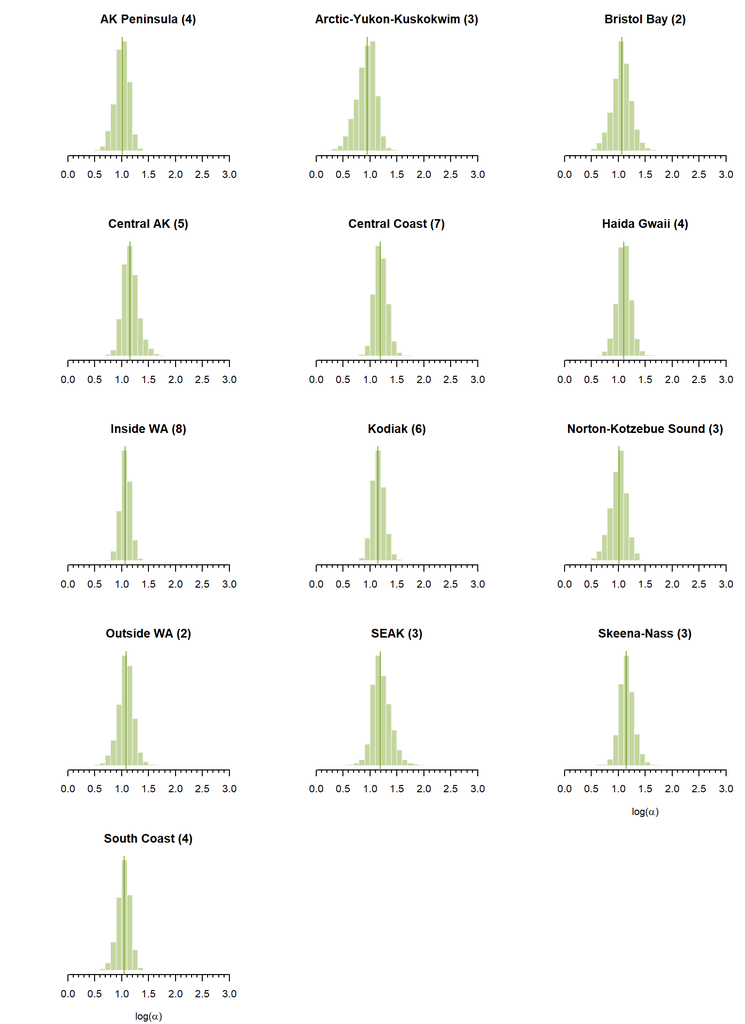

## 3.11 Table S6. Chum sub-region productivity

|  | region | n | mean | sd |
| --- | --- | --- | --- | --- |
| log_a_sr[1] | AK Peninsula | 4 | 1.00 | 0.13 |
| log_a_sr[2] | Arctic-Yukon-Kuskokwim | 3 | 0.93 | 0.18 |
| log_a_sr[3] | Bristol Bay | 2 | 1.06 | 0.18 |
| log_a_sr[4] | Central AK | 5 | 1.17 | 0.14 |
| log_a_sr[5] | Central Coast | 7 | 1.20 | 0.12 |
| log_a_sr[6] | Haida Gwaii | 4 | 1.10 | 0.13 |
| log_a_sr[7] | Inside WA | 8 | 1.07 | 0.09 |
| log_a_sr[8] | Kodiak | 6 | 1.16 | 0.11 |
| log_a_sr[9] | Norton-Kotzebue Sound | 3 | 1.00 | 0.15 |
| log_a_sr[10] | Outside WA | 2 | 1.08 | 0.14 |
| log_a_sr[11] | SEAK | 3 | 1.22 | 0.17 |
| log_a_sr[12] | Skeena-Nass | 3 | 1.16 | 0.14 |
| log_a_sr[13] | South Coast | 4 | 1.04 | 0.12 |

## 3.12 Fig. S11. Coho sub-region productivity

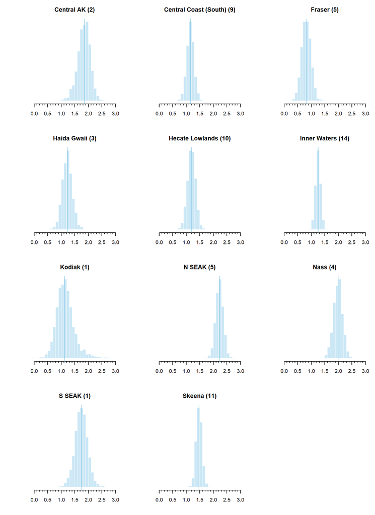

## 3.13 Table S7. Coho sub-region productivity

|  | region | n | mean | sd |
| --- | --- | --- | --- | --- |
| log_a_sr[1] | Central AK | 2 | 1.84 | 0.23 |
| log_a_sr[2] | Central Coast (South) | 9 | 1.15 | 0.13 |
| log_a_sr[3] | Fraser | 5 | 0.82 | 0.17 |
| log_a_sr[4] | Haida Gwaii | 3 | 1.22 | 0.18 |
| log_a_sr[5] | Hecate Lowlands | 10 | 1.20 | 0.15 |
| log_a_sr[6] | Inner Waters | 14 | 1.25 | 0.09 |
| log_a_sr[7] | Kodiak | 1 | 1.16 | 0.33 |
| log_a_sr[8] | N SEAK | 5 | 2.23 | 0.14 |
| log_a_sr[9] | Nass | 4 | 1.99 | 0.16 |
| log_a_sr[10] | S SEAK | 1 | 1.74 | 0.24 |
| log_a_sr[11] | Skeena | 11 | 1.47 | 0.11 |

## 3.14 Fig. S12. Pink (even-year) sub-region productivity

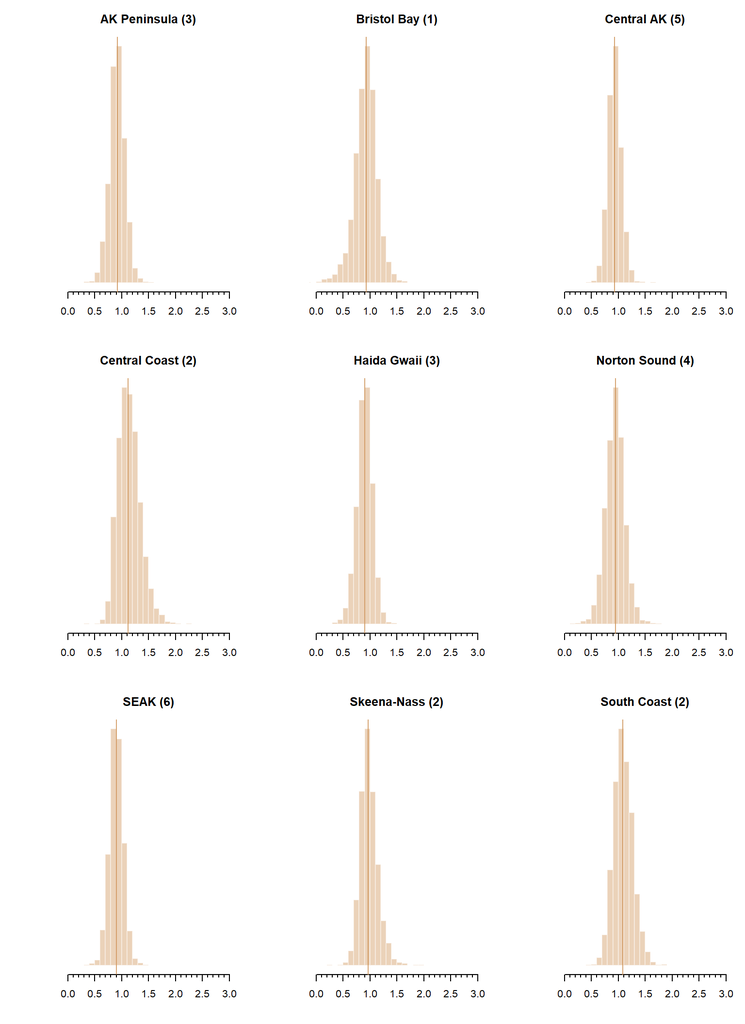

## 3.15 Table S8. Pink (even-year) sub-region productivity

|  | region | n | mean | sd |
| --- | --- | --- | --- | --- |
| log_a_sr[1] | AK Peninsula | 3 | 0.92 | 0.14 |
| log_a_sr[2] | Bristol Bay | 1 | 0.92 | 0.21 |
| log_a_sr[3] | Central AK | 5 | 0.94 | 0.12 |
| log_a_sr[4] | Central Coast | 2 | 1.14 | 0.20 |
| log_a_sr[5] | Haida Gwaii | 3 | 0.90 | 0.14 |
| log_a_sr[6] | Norton Sound | 4 | 0.94 | 0.18 |
| log_a_sr[7] | SEAK | 6 | 0.90 | 0.13 |
| log_a_sr[8] | Skeena-Nass | 2 | 0.99 | 0.16 |
| log_a_sr[9] | South Coast | 2 | 1.09 | 0.18 |

## 3.16 Fig. S13. Pink (odd-year) sub-region productivity

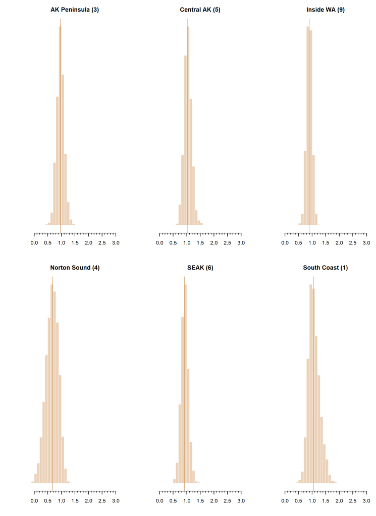

## 3.17 Table S9. Pink (odd-year) sub-region productivity

|  | region | n | mean | sd |
| --- | --- | --- | --- | --- |
| log_a_sr[1] | AK Peninsula | 3 | 0.96 | 0.14 |
| log_a_sr[2] | Central AK | 5 | 1.04 | 0.14 |
| log_a_sr[3] | Inside WA | 9 | 0.90 | 0.10 |
| log_a_sr[4] | Norton Sound | 4 | 0.66 | 0.23 |
| log_a_sr[5] | SEAK | 6 | 0.93 | 0.13 |
| log_a_sr[6] | South Coast | 1 | 1.08 | 0.21 |

## 3.18 Fig. S14. Variance in productivity across spatial scales

The proportional variances for differences in the productivity parameter, log($\alpha$), at each hierarchical spatial scale, representing the median estimates of $\sigma^2$ relative to their sum from the static hierarchical model (eq. 1).

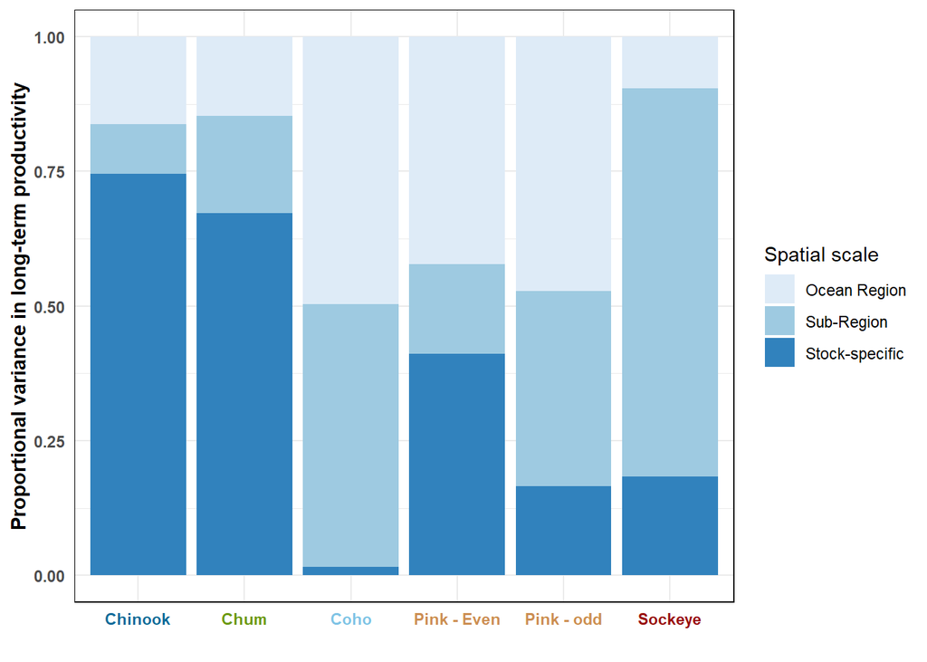

| species | percent.var | scale |
| --- | --- | --- |
| Chinook | 0.1619396 | Ocean Region |
| Chinook | 0.0930266 | Sub-Region |
| Chinook | 0.7450338 | Stock-specific |
| Sockeye | 0.0961017 | Ocean Region |
| Sockeye | 0.7204203 | Sub-Region |
| Sockeye | 0.1834780 | Stock-specific |
| Chum | 0.1465116 | Ocean Region |
| Chum | 0.1813348 | Sub-Region |
| Chum | 0.6721535 | Stock-specific |
| Coho | 0.4965236 | Ocean Region |
| Coho | 0.4881443 | Sub-Region |
| Coho | 0.0153321 | Stock-specific |
| Pink - Even | 0.4216759 | Ocean Region |
| Pink - Even | 0.1675684 | Sub-Region |
| Pink - Even | 0.4107557 | Stock-specific |
| Pink - odd | 0.4717853 | Ocean Region |
| Pink - odd | 0.3630116 | Sub-Region |
| Pink - odd | 0.1652032 | Stock-specific |

## 3.19 Table S10. Stock-specific productivity

Mean and standard deviation in the estimate of long-term average (or equilibrium) productivity for each stock examined in the hierarchical static model.

| stock | ocean.region | sub.region | mean | sd |
| --- | --- | --- | --- | --- |
| Ayakulik-Chinook | GoA | Kodiak | 1.04 | 0.30 |
| Karluk-Chinook | GoA | Kodiak | 1.02 | 0.33 |
| Chignik-Chinook | GoA | AK Peninsula | 1.32 | 0.28 |
| Nelson-Chinook | GoA | AK Peninsula | 1.24 | 0.22 |
| Goodnews-Chinook | BS | Kuskokwim | 1.10 | 0.24 |
| Andrew Creek-Chinook | NC | SEAK | 0.50 | 0.17 |
| Chickamin-Chinook | NC | SEAK | 0.41 | 0.23 |
| King Salmon River-Chinook | NC | SEAK | 0.31 | 0.09 |
| Stikine-Chinook | NC | SEAK | 0.85 | 0.26 |
| Unuk-Chinook | NC | SEAK | 0.46 | 0.18 |
| Alsek-Klukshu-Chinook | NC | SEAK | 1.07 | 0.39 |
| Situk-Chinook | NC | SEAK | 1.03 | 0.34 |
| Nushagak-Chinook | BS | Bristol Bay | 1.31 | 0.25 |
| Copper-Chinook | GoA | Central AK | 1.28 | 0.22 |
| Deshka-Chinook | GoA | Central AK | 1.14 | 0.33 |
| Susitna-Chinook | GoA | Central AK | 1.25 | 0.29 |
| Talkeetna-Chinook | GoA | Central AK | 0.91 | 0.29 |
| Yentna-Chinook | GoA | Central AK | 1.39 | 0.26 |
| Kenai - Early-Chinook | GoA | Central AK | 1.18 | 0.32 |
| Kenai - Late-Chinook | GoA | Central AK | 1.07 | 0.34 |
| Blossom-Chinook | NC | SEAK | 0.86 | 0.32 |
| Keta-Chinook | NC | SEAK | 1.04 | 0.29 |
| Anchor-Chinook | GoA | Central AK | 0.96 | 0.36 |
| East Fork Andreafsky-Chinook | BS | Yukon | 1.20 | 0.31 |
| Gisasa-Chinook | BS | Yukon | 0.45 | 0.30 |
| Salcha-Chinook | BS | Yukon | 1.50 | 0.27 |
| Chena-Chinook | BS | Yukon | 1.12 | 0.27 |
| Aniak-Chinook | BS | Kuskokwim | 1.28 | 0.30 |
| George-Chinook | BS | Kuskokwim | 0.62 | 0.23 |
| Holokuk-Chinook | BS | Kuskokwim | 0.86 | 0.34 |

[output cut: 326 more lines]

## 3.20 Capacity (Smax)

## 3.21 Fig. S15. Smax posteriors by species

Posterior distribution of $S_{max}$, the spawners where total recruits is maximized (=1/$\beta$), for all stocks of each species. Darker bars indicate the distribution of median estimates among all stocks.

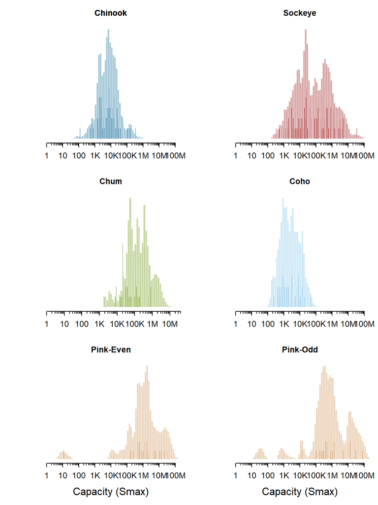

## 3.22 Table S11. Stock-specific Smax

Stock-specific estimates of $S_{max}$, the spawners where total recruits is maximized (=1/$\beta$), which are estimated independently with informative priors (see main text and above). Note all values are expressed as thousands of spawners.

| stock | ocean.region | sub.region | mean | sd |
| --- | --- | --- | --- | --- |
| Ayakulik-Chinook | GoA | Kodiak | 13.13 | 4.30 |
| Karluk-Chinook | GoA | Kodiak | 10.63 | 4.59 |
| Chignik-Chinook | GoA | AK Peninsula | 4.13 | 1.58 |
| Nelson-Chinook | GoA | AK Peninsula | 6.88 | 2.86 |
| Goodnews-Chinook | BS | Kuskokwim | 5.30 | 2.97 |
| Andrew Creek-Chinook | NC | SEAK | 7.18 | 3.17 |
| Chickamin-Chinook | NC | SEAK | 25.81 | 8.39 |
| King Salmon River-Chinook | NC | SEAK | 1.43 | 0.43 |
| Stikine-Chinook | NC | SEAK | 65.16 | 43.92 |
| Unuk-Chinook | NC | SEAK | 31.83 | 10.67 |
| Alsek-Klukshu-Chinook | NC | SEAK | 3.05 | 2.27 |
| Situk-Chinook | NC | SEAK | 4.91 | 3.98 |
| Nushagak-Chinook | BS | Bristol Bay | 168.12 | 43.35 |
| Copper-Chinook | GoA | Central AK | 119.27 | 62.72 |
| Deshka-Chinook | GoA | Central AK | 25.13 | 11.45 |
| Susitna-Chinook | GoA | Central AK | 23.19 | 3.43 |
| Talkeetna-Chinook | GoA | Central AK | 32.14 | 22.23 |
| Yentna-Chinook | GoA | Central AK | 23.03 | 3.89 |
| Kenai - Early-Chinook | GoA | Central AK | 6.82 | 1.14 |
| Kenai - Late-Chinook | GoA | Central AK | 39.01 | 13.04 |
| Blossom-Chinook | NC | SEAK | 2.50 | 1.21 |
| Keta-Chinook | NC | SEAK | 2.00 | 0.93 |
| Anchor-Chinook | GoA | Central AK | 10.74 | 8.75 |
| East Fork Andreafsky-Chinook | BS | Yukon | 3.95 | 2.04 |
| Gisasa-Chinook | BS | Yukon | 7.83 | 4.41 |
| Salcha-Chinook | BS | Yukon | 7.83 | 2.17 |
| Chena-Chinook | BS | Yukon | 11.40 | 6.58 |
| Aniak-Chinook | BS | Kuskokwim | 12.95 | 3.32 |
| George-Chinook | BS | Kuskokwim | 22.97 | 15.29 |
| Holokuk-Chinook | BS | Kuskokwim | 1.64 | 0.81 |

[output cut: 326 more lines]

## 3.23 Recruitment variance (Sigma)

## 3.24 Fig. S16. Sigma posteriors by species

Posterior distribution of $\sigma$, the residual deviance in log($R/S$), for all stocks of each species. Darker bars indicate the distribution of median estimates among all stocks and black vertical lines represent the median of the entire posterior.

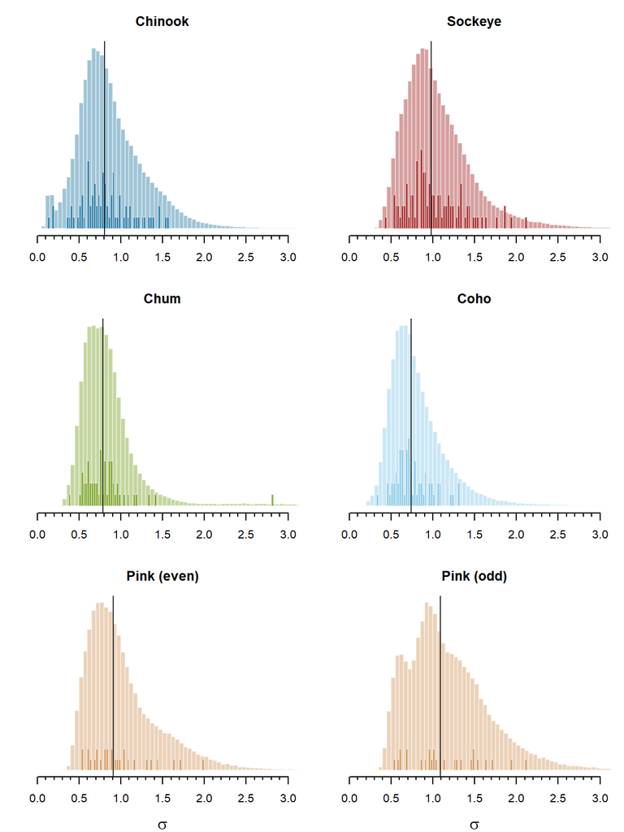

## 3.25 Table S12. Sigma by species

| stock | ocean.region | sub.region | mean | sd |
| --- | --- | --- | --- | --- |
| Ayakulik-Chinook | GoA | Kodiak | 0.91 | 0.33 |
| Karluk-Chinook | GoA | Kodiak | 0.89 | 0.41 |
| Chignik-Chinook | GoA | AK Peninsula | 0.69 | 0.26 |
| Nelson-Chinook | GoA | AK Peninsula | 0.42 | 0.21 |
| Goodnews-Chinook | BS | Kuskokwim | 0.51 | 0.13 |
| Andrew Creek-Chinook | NC | SEAK | 0.43 | 0.21 |
| Chickamin-Chinook | NC | SEAK | 0.29 | 0.30 |
| King Salmon River-Chinook | NC | SEAK | 0.16 | 0.09 |
| Stikine-Chinook | NC | SEAK | 0.65 | 0.17 |
| Unuk-Chinook | NC | SEAK | 0.25 | 0.23 |
| Alsek-Klukshu-Chinook | NC | SEAK | 0.73 | 0.45 |
| Situk-Chinook | NC | SEAK | 1.10 | 0.40 |
| Nushagak-Chinook | BS | Bristol Bay | 0.58 | 0.16 |
| Copper-Chinook | GoA | Central AK | 0.68 | 0.14 |
| Deshka-Chinook | GoA | Central AK | 0.87 | 0.18 |
| Susitna-Chinook | GoA | Central AK | 0.61 | 0.33 |
| Talkeetna-Chinook | GoA | Central AK | 0.72 | 0.17 |
| Yentna-Chinook | GoA | Central AK | 0.52 | 0.24 |
| Kenai - Early-Chinook | GoA | Central AK | 0.89 | 0.43 |
| Kenai - Late-Chinook | GoA | Central AK | 0.82 | 0.46 |
| Blossom-Chinook | NC | SEAK | 1.00 | 0.41 |
| Keta-Chinook | NC | SEAK | 0.71 | 0.29 |
| Anchor-Chinook | GoA | Central AK | 0.75 | 0.44 |
| East Fork Andreafsky-Chinook | BS | Yukon | 0.72 | 0.23 |
| Gisasa-Chinook | BS | Yukon | 0.60 | 0.25 |
| Salcha-Chinook | BS | Yukon | 0.71 | 0.20 |
| Chena-Chinook | BS | Yukon | 0.73 | 0.15 |
| Aniak-Chinook | BS | Kuskokwim | 0.75 | 0.23 |
| George-Chinook | BS | Kuskokwim | 0.69 | 0.19 |
| Holokuk-Chinook | BS | Kuskokwim | 1.43 | 0.26 |

[output cut: 326 more lines]

## 3.26 Table S13. Sigma by ocean region

| species | ocean.region | n | mean | sd |
| --- | --- | --- | --- | --- |
| Chinook | South Coast | 24 | 1.17 | 0.39 |
| Chinook | North Coast | 15 | 0.69 | 0.37 |
| Chinook | Gulf of Alaska | 16 | 0.72 | 0.37 |
| Chinook | Bering Sea | 25 | 0.83 | 0.36 |
| Chum | South Coast | 21 | 1.28 | 0.46 |
| Chum | North Coast | 10 | 0.99 | 0.34 |
| Chum | Gulf of Alaska | 12 | 0.80 | 0.32 |
| Chum | Bering Sea | 11 | 0.81 | 0.27 |
| Coho | South Coast | 38 | 0.85 | 0.22 |
| Coho | North Coast | 24 | 0.86 | 0.33 |
| Coho | Gulf of Alaska | 3 | 1.01 | 0.71 |
| Pink (even) | South Coast | 4 | 0.76 | 0.27 |
| Pink (even) | North Coast | 11 | 0.88 | 0.38 |
| Pink (even) | Gulf of Alaska | 7 | 0.77 | 0.32 |
| Pink (even) | Bering Sea | 6 | 0.55 | 0.30 |
| Pink (odd) | South Coast | 10 | 0.97 | 0.26 |
| Pink (odd) | North Coast | 6 | 0.89 | 0.30 |
| Pink (odd) | Gulf of Alaska | 7 | 0.84 | 0.34 |
| Pink (odd) | Bering Sea | 5 | 1.49 | 0.49 |
| Sockeye | South Coast | 44 | 0.96 | 0.14 |
| Sockeye | North Coast | 28 | 0.99 | 0.13 |
| Sockeye | Gulf of Alaska | 17 | 0.90 | 0.05 |
| Sockeye | Bering Sea | 12 | 1.05 | 0.12 |

## 3.27 Table S14 Stock-specific Sigma

Stock-specific estimates of $\sigma$, the residual deviance in log($R/S$).

| stock | ocean.region | sub.region | mean | sd |
| --- | --- | --- | --- | --- |
| Ayakulik-Chinook | GoA | Kodiak | 0.91 | 0.33 |
| Karluk-Chinook | GoA | Kodiak | 0.89 | 0.41 |
| Chignik-Chinook | GoA | AK Peninsula | 0.69 | 0.26 |
| Nelson-Chinook | GoA | AK Peninsula | 0.42 | 0.21 |
| Goodnews-Chinook | BS | Kuskokwim | 0.51 | 0.13 |
| Andrew Creek-Chinook | NC | SEAK | 0.43 | 0.21 |
| Chickamin-Chinook | NC | SEAK | 0.29 | 0.30 |
| King Salmon River-Chinook | NC | SEAK | 0.16 | 0.09 |
| Stikine-Chinook | NC | SEAK | 0.65 | 0.17 |
| Unuk-Chinook | NC | SEAK | 0.25 | 0.23 |
| Alsek-Klukshu-Chinook | NC | SEAK | 0.73 | 0.45 |
| Situk-Chinook | NC | SEAK | 1.10 | 0.40 |
| Nushagak-Chinook | BS | Bristol Bay | 0.58 | 0.16 |
| Copper-Chinook | GoA | Central AK | 0.68 | 0.14 |
| Deshka-Chinook | GoA | Central AK | 0.87 | 0.18 |
| Susitna-Chinook | GoA | Central AK | 0.61 | 0.33 |
| Talkeetna-Chinook | GoA | Central AK | 0.72 | 0.17 |
| Yentna-Chinook | GoA | Central AK | 0.52 | 0.24 |
| Kenai - Early-Chinook | GoA | Central AK | 0.89 | 0.43 |
| Kenai - Late-Chinook | GoA | Central AK | 0.82 | 0.46 |
| Blossom-Chinook | NC | SEAK | 1.00 | 0.41 |
| Keta-Chinook | NC | SEAK | 0.71 | 0.29 |
| Anchor-Chinook | GoA | Central AK | 0.75 | 0.44 |
| East Fork Andreafsky-Chinook | BS | Yukon | 0.72 | 0.23 |
| Gisasa-Chinook | BS | Yukon | 0.60 | 0.25 |
| Salcha-Chinook | BS | Yukon | 0.71 | 0.20 |
| Chena-Chinook | BS | Yukon | 0.73 | 0.15 |
| Aniak-Chinook | BS | Kuskokwim | 0.75 | 0.23 |
| George-Chinook | BS | Kuskokwim | 0.69 | 0.19 |
| Holokuk-Chinook | BS | Kuskokwim | 1.43 | 0.26 |

[output cut: 326 more lines]

## 3.28 Rho (autocorrelation)

## 3.29 Fig. S17. Rho by species

Posterior distribution of $\rho$, the 1-year residual autocorrelation parameter, for all stocks of each species. Darker bars indicate the distribution of median estimates among all stocks and black vertical lines represent the median of the entire posterior.

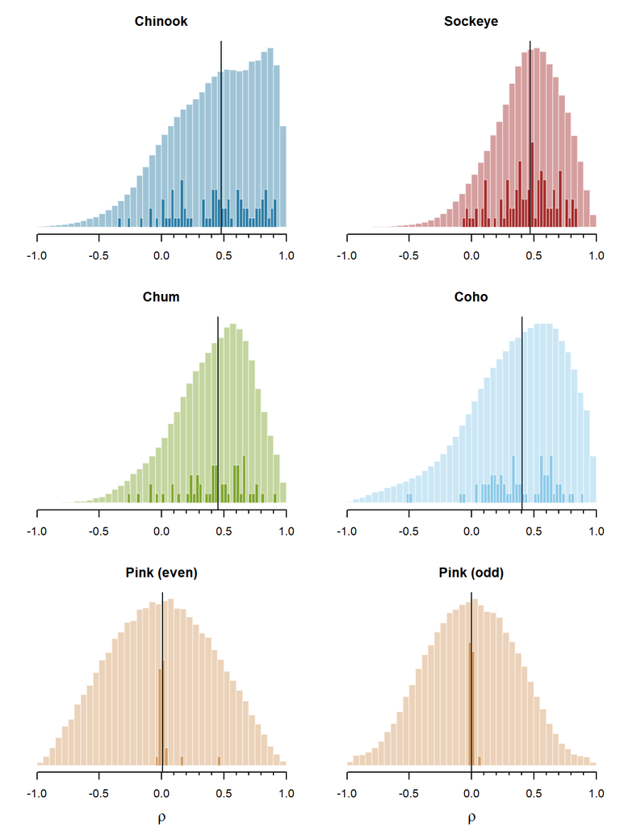

## 3.30 Table S15. Rho by species

Stock-specific estimates of $\rho$, the autocorrelation in residual deviance of log($R/S$).

| stock | ocean.region | sub.region | mean | sd |
| --- | --- | --- | --- | --- |
| Ayakulik-Chinook | GoA | Kodiak | 0.73 | 0.13 |
| Karluk-Chinook | GoA | Kodiak | 0.82 | 0.10 |
| Chignik-Chinook | GoA | AK Peninsula | 0.62 | 0.19 |
| Nelson-Chinook | GoA | AK Peninsula | 0.38 | 0.31 |
| Goodnews-Chinook | BS | Kuskokwim | -0.31 | 0.24 |
| Andrew Creek-Chinook | NC | SEAK | 0.06 | 0.50 |
| Chickamin-Chinook | NC | SEAK | 0.62 | 0.27 |
| King Salmon River-Chinook | NC | SEAK | 0.07 | 0.34 |
| Stikine-Chinook | NC | SEAK | 0.19 | 0.26 |
| Unuk-Chinook | NC | SEAK | 0.46 | 0.31 |
| Alsek-Klukshu-Chinook | NC | SEAK | 0.31 | 0.44 |
| Situk-Chinook | NC | SEAK | 0.61 | 0.19 |
| Nushagak-Chinook | BS | Bristol Bay | 0.52 | 0.17 |
| Copper-Chinook | GoA | Central AK | 0.44 | 0.17 |
| Deshka-Chinook | GoA | Central AK | 0.47 | 0.17 |
| Susitna-Chinook | GoA | Central AK | 0.91 | 0.06 |
| Talkeetna-Chinook | GoA | Central AK | 0.42 | 0.19 |
| Yentna-Chinook | GoA | Central AK | 0.65 | 0.17 |
| Kenai - Early-Chinook | GoA | Central AK | 0.87 | 0.08 |
| Kenai - Late-Chinook | GoA | Central AK | 0.89 | 0.08 |
| Blossom-Chinook | NC | SEAK | 0.80 | 0.11 |
| Keta-Chinook | NC | SEAK | 0.68 | 0.16 |
| Anchor-Chinook | GoA | Central AK | 0.46 | 0.38 |
| East Fork Andreafsky-Chinook | BS | Yukon | -0.25 | 0.31 |
| Gisasa-Chinook | BS | Yukon | -0.11 | 0.39 |
| Salcha-Chinook | BS | Yukon | 0.42 | 0.21 |
| Chena-Chinook | BS | Yukon | 0.25 | 0.20 |
| Aniak-Chinook | BS | Kuskokwim | 0.61 | 0.16 |
| George-Chinook | BS | Kuskokwim | 0.44 | 0.19 |
| Holokuk-Chinook | BS | Kuskokwim | 0.33 | 0.18 |

[output cut: 326 more lines]

## 3.31 Parameter correlations

This section examines the correlation between estimates of different spawner-recruit parameters including stock productivity (log($\alpha$)), capacity ($Smax$), and recruitment deviance ($sigma$). We show correlations both across stocks, which tests for potential scaling relationships (ie. are larger stocks more or less productive or variable), and within the posterior sample for each stock, which gives an indication of the intrinsic correlation between intercepts and slopes in the estimation of the Ricker spawner-recruit model.

## 3.32 Fig. S18. Across stocks - productivity and capacity.

$r$ is the median correlation among stocks in each parameter.

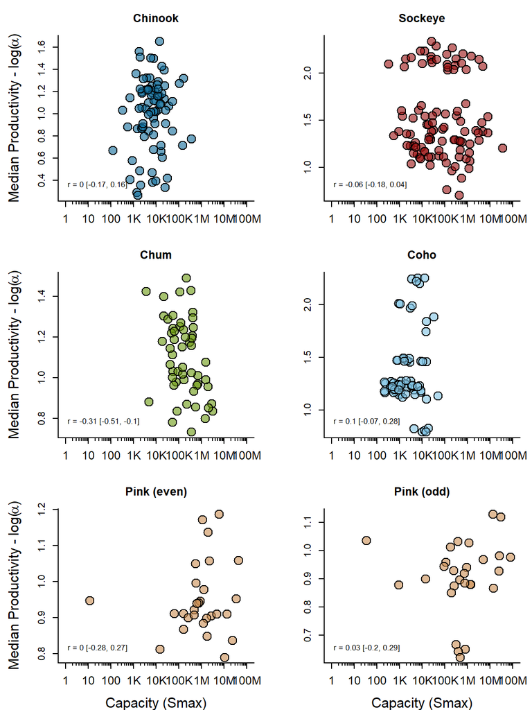

## 3.33 Fig. S19. Within stocks - productivity and capacity.

Distribution of the median correlation between each parameter in the posterior distribution of each stock.

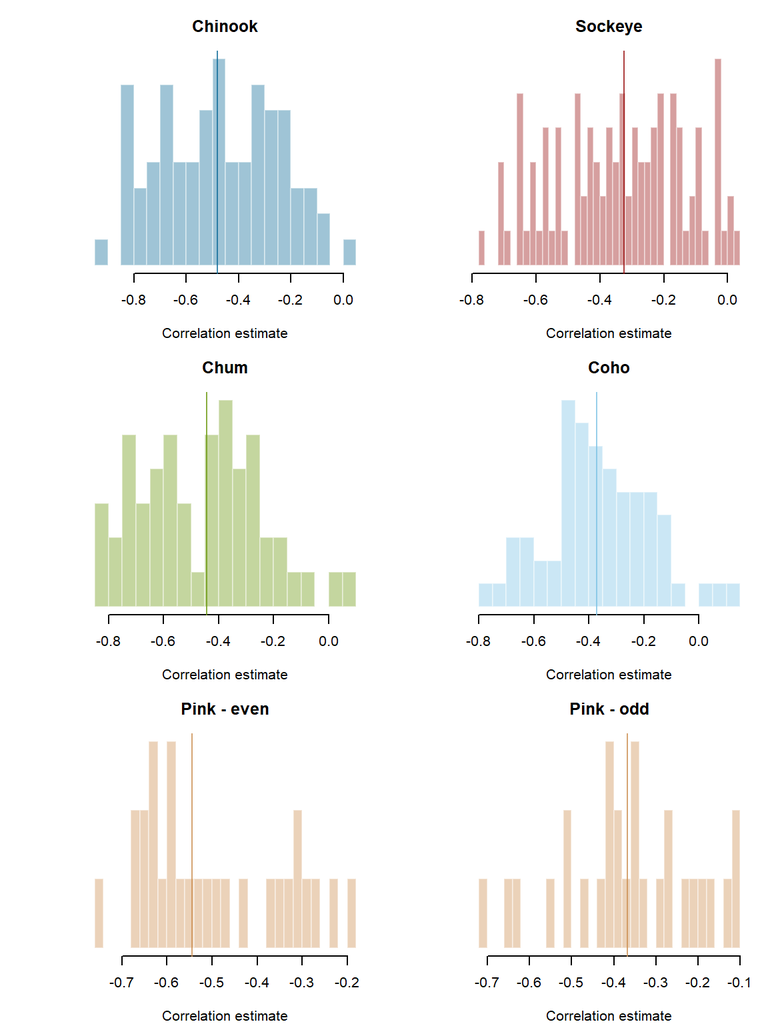

## 3.34 Fig. S20. Across stocks: Capacity and Sigma

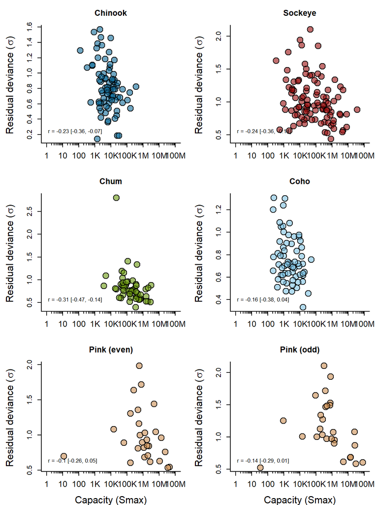

## 3.35 Fig. S21. Within stocks: Capacity and Sigma

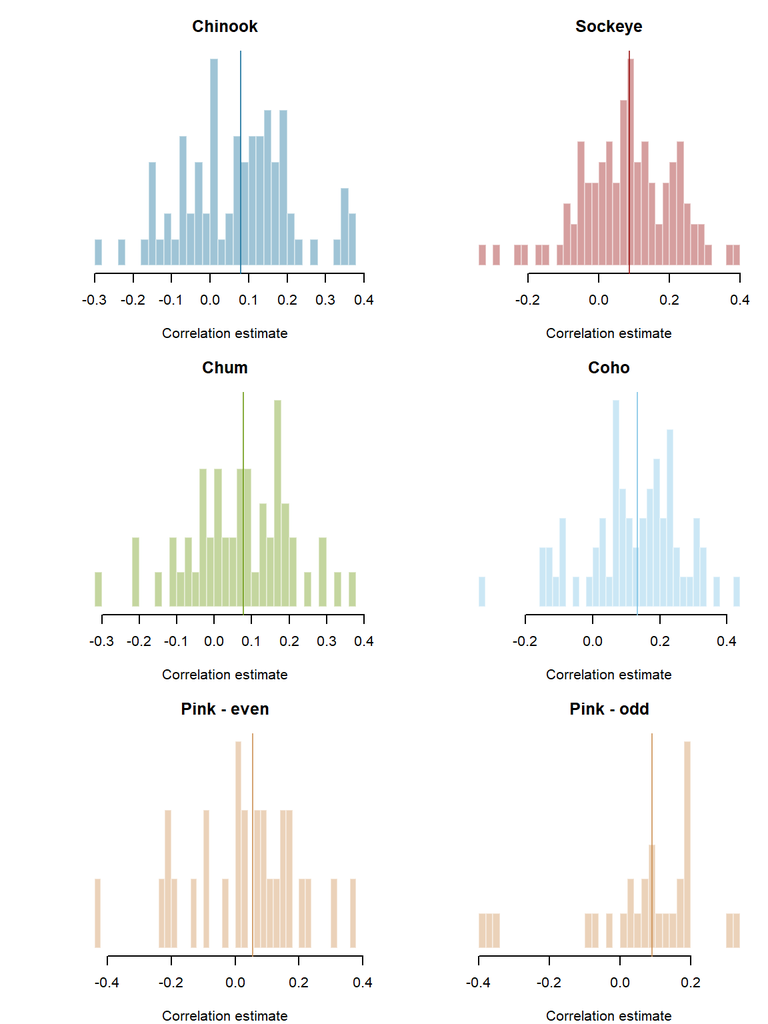